# mids-203-project

2026-04-09

```r
# Load libraries
library(ggplot2)
library(car)
library(lmtest)
# Read CSV (adjust path as needed)
df <- read.csv("merged_raw_all_years.csv")
dim(df)
```

```
## [1]  220 4966
```

Added column names bc i got a little confused -Malachi

```r
colnames(df)[grepl("PFL|FSS|CDA|CHA|FGA|NDA", colnames(df))]
```

```
##   [1] "CDA.raw.1999" "CDA.raw.2000" "CDA.raw.2001" "CDA.raw.2002" "CDA.raw.2003"
##   [6] "CDA.raw.2004" "CDA.raw.2005" "CDA.raw.2006" "CDA.raw.2007" "CDA.raw.2008"
##  [11] "CDA.raw.2009" "CDA.raw.2010" "CDA.raw.2011" "CDA.raw.2012" "CDA.raw.2013"
##  [16] "CDA.raw.2014" "CDA.raw.2015" "CDA.raw.2016" "CDA.raw.2017" "CDA.raw.2018"
##  [21] "CDA.raw.2019" "CDA.raw.2020" "CDA.raw.2021" "CDA.raw.2022" "CHA.raw.1999"
##  [26] "CHA.raw.2000" "CHA.raw.2001" "CHA.raw.2002" "CHA.raw.2003" "CHA.raw.2004"
##  [31] "CHA.raw.2005" "CHA.raw.2006" "CHA.raw.2007" "CHA.raw.2008" "CHA.raw.2009"
##  [36] "CHA.raw.2010" "CHA.raw.2011" "CHA.raw.2012" "CHA.raw.2013" "CHA.raw.2014"
##  [41] "CHA.raw.2015" "CHA.raw.2016" "CHA.raw.2017" "CHA.raw.2018" "CHA.raw.2019"
##  [46] "CHA.raw.2020" "CHA.raw.2021" "CHA.raw.2022" "NDA.raw.1999" "NDA.raw.2000"
##  [51] "NDA.raw.2001" "NDA.raw.2002" "NDA.raw.2003" "NDA.raw.2004" "NDA.raw.2005"
##  [56] "NDA.raw.2006" "NDA.raw.2007" "NDA.raw.2008" "NDA.raw.2009" "NDA.raw.2010"
##  [61] "NDA.raw.2011" "NDA.raw.2012" "NDA.raw.2013" "NDA.raw.2014" "NDA.raw.2015"
##  [66] "NDA.raw.2016" "NDA.raw.2017" "NDA.raw.2018" "NDA.raw.2019" "NDA.raw.2020"
##  [71] "NDA.raw.2021" "NDA.raw.2022" "FGA.raw.1999" "FGA.raw.2000" "FGA.raw.2001"
```

[output cut: 22 more lines]

First task: examine the data for cleanliness issues

- Realizing that a lot of the variables in the dataset are missing like 50% of the rows…so let’s first rank all the possible Y variables (in ‘ecosystem vitality on page 3’) and X variables (in ‘climate change on page 4’) based on how many NA rows there are, then choose based on a tradeoff between relevance and # of missing rows.
- I’m using 2019, which is the last year with fisheries data (see page 130/131)

```r
ecosystem_vars <- c(
  # Biodiversity & Habitat
  "MKP", "MHP", "MPE", "PAR", "SPI", "TBN", "TKP", "PAE", "PHL", "RLI", "SHI", "BER",

  # Forests
  "PFL", "IFL", "FCL", "TCG", "FLI",

  # Fisheries
  "FSS", "FCD", "BTZ", "BTO", "RMS",

  # Air Pollution
  "OEB", "OEC", "NXA", "SDA",

  # Agriculture
  "SNM", "PSU", "PRS", "RCY",

  # Water Resources
  "WWG", "WWC", "WWT", "WWR"
)

eco_col_matches <- colnames(df)[
  grepl(paste(ecosystem_vars, collapse = "|"), colnames(df)) &
    grepl("2019$", colnames(df))
]

df_ecosystem = df[, eco_col_matches]

# sort each column in the ecosystem vitality (ECO) category by the number of NAs in the year 2019
sort(colSums(is.na(df_ecosystem)))
```

```
## TBN.raw.2019 RLI.raw.2019 OEB.raw.2019 TKP.raw.2019 SNM.raw.2019 PSU.raw.2019
##            0            2            7            9           26           26
## NXA.raw.2019 SDA.raw.2019 OEC.raw.2019 SPI.raw.2019 SHI.raw.2019 BTO.raw.2019
##           29           29           32           42           43           51
## FCD.raw.2019 MHP.raw.2019 BTZ.raw.2019 RMS.raw.2019 FCL.raw.2019 MKP.raw.2019
##           59           65           71           72           74           79
## MPE.raw.2019 RCY.raw.2019 FSS.raw.2019 PFL.raw.2019 WWC.raw.2019 IFL.raw.2019
##           82           88          102          137          159          159
## WWT.raw.2019 WWG.raw.2019
##          165          187
```

Most relevant Y-variables would be: - PFL (primary forest loss) - 137 missing rows out of 220 - Alternative: FCL (74 missing rows) - FSS (fish stock status) - 102 missing rows out of 220 - Alternative: RLI/SHI - 2 and 43 missing rows - Could consider using TBN (terrestrial biome protection/biodiversity/ecosystem vitality) - not ideal but it has no missing data

Now to look at the x-variables:

```r
climate_vars <- c(
  # Climate Change Mitigation
  "CDA",  # Adjusted emissions growth rate for CO2
  "CDF",  # CO2 growth rate (country-specific targets)
  "CHA",  # Adjusted emissions growth rate for methane
  "FGA",  # Adjusted emissions growth rate for F-gases
  "NDA",  # Adjusted emissions growth rate for nitrous oxide
  "BCA",  # Adjusted emissions growth rate for black carbon
  "LUF",  # Net carbon fluxes due to land cover change
  "GTI",  # GHG growth rate adjusted by emissions intensity
  "GTP",  # GHG growth rate adjusted by per capita emissions
  "GHN",  # Projected emissions in 2050
  "CBP"   # Projected cumulative emissions to 2050 relative to carbon budget,
)

climate_col_matches <- colnames(df)[
  grepl(paste(climate_vars, collapse = "|"), colnames(df)) &
    grepl("2019$", colnames(df))
]

df_climate = df[, climate_col_matches]

# sort each column in the ecosystem vitality (ECO) category by the number of NAs in the year 2019
sort(colSums(is.na(df_climate)))
```

```
## CDA.raw.2019 CDF.raw.2019 GTI.raw.2019 GHN.raw.2019 GTP.raw.2019 BCA.raw.2019
##           26           26           26           26           26           27
## CHA.raw.2019 NDA.raw.2019 LUF.raw.2019 FGA.raw.2019
##           30           30           39           68
```

We can also investigate how much missing data is in the GDP for 2019:

```r
sum(is.na(df[, 'GDP.raw.2019']))
```

```
## [1] 20
```

What if we looked at only our best variables of interest and saw how small that dataset would be?

```r
vars_y <- c("PFL", "FSS")
vars_x <- c("CDO", "CH4", "FOG", "NOT")
vars_z <- c("GDP")
patterns <- c(vars_y,vars_x,vars_z)


cols_matched <- colnames(df)[
  grepl(paste(patterns, collapse = "|"), colnames(df)) &
  grepl("2019$", colnames(df))
]

df_2019 <- df[, c("code", "iso", "country", cols_matched)]
# How much data are we left with if we remove all rows with NA in any of these columns of interest?

df_2019_clean <- na.omit(df_2019)
dim(df_2019_clean)
```

```
## [1] 43 10
```

```r
summary(df_2019_clean[, cols_matched])
```

```
##   NOT.raw.2019       GDP.raw.2019        PFL.raw.2019        CDO.raw.2019
##  Min.   :   0.176   Min.   :1.108e+10   Min.   :0.0001165   Min.   :    1408
##  1st Qu.:  10.920   1st Qu.:5.540e+10   1st Qu.:0.0014836   1st Qu.:    9179
##  Median :  23.100   Median :1.977e+11   Median :0.0028603   Median :   28375
##  Mean   : 144.340   Mean   :1.733e+12   Mean   :0.0055024   Mean   :  533175
##  3rd Qu.:  88.300   3rd Qu.:9.869e+11   3rd Qu.:0.0072342   3rd Qu.:  223003
##  Max.   :1540.000   Max.   :2.249e+13   Max.   :0.0273694   Max.   :10721042
##   FSS.raw.2019      FOG.raw.2019     CH4.raw.2019
##  Min.   : 0.0100   Min.   :     0   Min.   :   30.5
##  1st Qu.: 0.7119   1st Qu.:   439   1st Qu.:  436.5
##  Median : 1.9698   Median :  1020   Median :  906.0
##  Mean   : 4.7003   Mean   : 19499   Mean   : 4974.1
##  3rd Qu.: 3.9114   3rd Qu.:  7755   3rd Qu.: 3775.0
##  Max.   :53.5000   Max.   :427000   Max.   :58200.0
```

It appears that for 2019, which is the last year that we still have fisheries data (FSS), we only have 43 countries that have data for all the variables of interest.

Checking pairwise for countries if we just do a direct X and Y relationship

```r
vars_y <- c("PFL", "FSS")
vars_x <- c("CDA", "CHA", "FGA", "NDA")
control <- "GDP"
year <- "2019"

pair_2019 <- do.call(rbind, lapply(vars_y, function(yv) {
  do.call(rbind, lapply(vars_x, function(xv) {
    cols <- c(
      paste0(yv, ".raw.", year),
      paste0(xv, ".raw.", year),
      paste0(control, ".raw.", year)
    )

    temp <- df[, c("country", cols)]

    data.frame(
      y_var = yv,
      x_var = xv,
      year = as.integer(year),
      n_countries = nrow(na.omit(temp))
    )
  }))
}))

pair_2019[order(-pair_2019$n_countries), ]
```

```
##   y_var x_var year n_countries
## 5   FSS   CDA 2019         116
## 6   FSS   CHA 2019         116
## 8   FSS   NDA 2019         116
## 7   FSS   FGA 2019          91
## 1   PFL   CDA 2019          80
## 2   PFL   CHA 2019          79
## 4   PFL   NDA 2019          79
## 3   PFL   FGA 2019          59
```

Checking Year overlaps

```r
vars_y <- c("PFL", "FSS")
vars_x <- c("CDA", "CHA", "FGA", "NDA")

get_years <- function(var, data) {
  cols <- colnames(data)[grepl(paste0("^", var, "\\.raw\\."), colnames(data))]
  sub(paste0("^", var, "\\.raw\\.(\\d{4})$"), "\\1", cols)
}

count_pair_nonmissing <- function(y_var, x_var, year, data) {
  y_col <- paste0(y_var, ".raw.", year)
  x_col <- paste0(x_var, ".raw.", year)

  if (!(y_col %in% colnames(data)) || !(x_col %in% colnames(data))) return(NA_integer_)

  sum(!is.na(data[[y_col]]) & !is.na(data[[x_col]]))
}

pair_results <- do.call(rbind, lapply(vars_y, function(yv) {
  do.call(rbind, lapply(vars_x, function(xv) {

    overlap_years <- sort(intersect(get_years(yv, df), get_years(xv, df)))

    if (length(overlap_years) == 0) {
      return(data.frame(
        y_var = yv,
        x_var = xv,
        n_overlap_years = 0,
        overlap_years = NA_character_,
        best_year = NA_character_,
        best_n_complete = NA_integer_
      ))
    }

    counts <- sapply(overlap_years, function(yr) count_pair_nonmissing(yv, xv, yr, df))
    best_idx <- which.max(counts)

    data.frame(
      y_var = yv,
      x_var = xv,
      n_overlap_years = length(overlap_years),
      overlap_years = paste(overlap_years, collapse = ", "),
      best_year = overlap_years[best_idx],
      best_n_complete = counts[best_idx]
    )
  }))
}))

pair_results[order(-pair_results$best_n_complete), ]
```

```
##       y_var x_var n_overlap_years
## 2013    FSS   CDA              21
## 20131   FSS   CHA              21
## 20132   FSS   NDA              21
## 2010    FSS   FGA              21
## 2018    PFL   CDA              17
## 20181   PFL   CHA              17
## 20182   PFL   NDA              17
## 2006    PFL   FGA              17
##                                                                                                                      overlap_years
## 2013  1999, 2000, 2001, 2002, 2003, 2004, 2005, 2006, 2007, 2008, 2009, 2010, 2011, 2012, 2013, 2014, 2015, 2016, 2017, 2018, 2019
## 20131 1999, 2000, 2001, 2002, 2003, 2004, 2005, 2006, 2007, 2008, 2009, 2010, 2011, 2012, 2013, 2014, 2015, 2016, 2017, 2018, 2019
## 20132 1999, 2000, 2001, 2002, 2003, 2004, 2005, 2006, 2007, 2008, 2009, 2010, 2011, 2012, 2013, 2014, 2015, 2016, 2017, 2018, 2019
## 2010  1999, 2000, 2001, 2002, 2003, 2004, 2005, 2006, 2007, 2008, 2009, 2010, 2011, 2012, 2013, 2014, 2015, 2016, 2017, 2018, 2019
## 2018                          2006, 2007, 2008, 2009, 2010, 2011, 2012, 2013, 2014, 2015, 2016, 2017, 2018, 2019, 2020, 2021, 2022
## 20181                         2006, 2007, 2008, 2009, 2010, 2011, 2012, 2013, 2014, 2015, 2016, 2017, 2018, 2019, 2020, 2021, 2022
## 20182                         2006, 2007, 2008, 2009, 2010, 2011, 2012, 2013, 2014, 2015, 2016, 2017, 2018, 2019, 2020, 2021, 2022
## 2006                          2006, 2007, 2008, 2009, 2010, 2011, 2012, 2013, 2014, 2015, 2016, 2017, 2018, 2019, 2020, 2021, 2022
##       best_year best_n_complete
## 2013       2013             116
## 20131      2013             116
## 20132      2013             116
## 2010       2010              91
## 2018       2018              81
## 20181      2018              80
## 20182      2018              80
## 2006       2006              60
```

## Variable Selection Decision

```r
n_fcl     <- sum(!is.na(df[["FCL.raw.2012"]]))
n_pfl     <- sum(!is.na(df[["PFL.raw.2012"]]))
r_fcl_pfl <- round(cor(df[["FCL.raw.2012"]], df[["PFL.raw.2012"]],
                        use = "complete.obs"), 3)

temp <- data.frame(
  POP     = df[["POP.raw.2012"]],
  CDO     = df[["CDO.raw.2012"]],
  NOX     = df[["NOX.raw.2012"]],
  SO2     = df[["SO2.raw.2012"]],
  CH4     = df[["CH4.raw.2012"]],
  FCL     = df[["FCL.raw.2012"]],
  GDP     = df[["GDP.raw.2012"]],
  HPE     = df[["HPE.raw.2012"]],
  SNM     = df[["SNM.raw.2012"]],
  GDP_pc  = df[["GPC.raw.2012"]]
)
temp$log_CDO <- log(pmax(temp$CDO, 1e-10))
temp$log_NOX <- log(pmax(temp$NOX, 1e-10))
temp$log_SO2 <- log(pmax(temp$SO2, 1e-10))
temp$log_CH4 <- log(pmax(temp$CH4, 1e-10))
temp$log_FCL <- log(pmax(temp$FCL, 1e-10))
temp$log_GDP <- log(pmax(temp$GDP, 1e-10))
temp$log_POP <- log(pmax(temp$POP, 1e-10))
temp$log_SNM <- log(pmax(temp$SNM, 1e-10))
temp <- na.omit(temp)

r_cdo_fcl <- round(cor(temp$log_CDO, temp$log_FCL), 3)
r_so2_fcl <- round(cor(temp$log_SO2, temp$log_FCL), 3)
r_ch4_fcl <- round(cor(temp$log_CH4, temp$log_FCL), 3)
r_snm_fcl <- round(cor(temp$log_SNM, temp$log_FCL), 3)
r_hpe_fcl <- round(cor(temp$HPE,     temp$log_FCL), 3)
r_cdo_gdp <- round(cor(temp$log_CDO, temp$log_GDP), 3)
r_cdo_so2 <- round(cor(temp$log_CDO, temp$log_SO2), 3)
r_cdo_ch4 <- round(cor(temp$log_CDO, temp$log_CH4), 3)
r_cdo_nox <- round(cor(temp$log_CDO, temp$log_NOX), 3)
r_cdo_snm <- round(cor(temp$log_CDO, temp$log_SNM), 3)

cat("FCL complete cases (2012):", n_fcl, "\n")
```

```
## FCL complete cases (2012): 150
```

```r
cat("PFL complete cases (2012):", n_pfl, "\n")
```

```
## PFL complete cases (2012): 83
```

```r
cat("r(FCL, PFL):", r_fcl_pfl, "\n")
```

```
## r(FCL, PFL): 0.834
```

```r
cat("r(log_CDO, log_FCL):", r_cdo_fcl, "\n")
```

```
## r(log_CDO, log_FCL): 0.12
```

```r
cat("r(log_SO2, log_FCL):", r_so2_fcl, "\n")
```

```
## r(log_SO2, log_FCL): 0.13
```

```r
cat("r(log_CH4, log_FCL):", r_ch4_fcl, "\n")
```

```
## r(log_CH4, log_FCL): 0.238
```

```r
cat("r(HPE,     log_FCL):", r_hpe_fcl, "\n")
```

```
## r(HPE,     log_FCL): -0.091
```

```r
cat("r(log_SNM, log_FCL):", r_snm_fcl, "\n")
```

```
## r(log_SNM, log_FCL): -0.23
```

```r
cat("r(log_CDO, log_GDP):", r_cdo_gdp, "\n")
```

```
## r(log_CDO, log_GDP): 0.97
```

```r
cat("r(log_CDO, log_SO2):", r_cdo_so2, "\n")
```

```
## r(log_CDO, log_SO2): 0.894
```

```r
cat("r(log_CDO, log_SNM):", r_cdo_snm, "\n")
```

```
## r(log_CDO, log_SNM): -0.294
```

**Y: FCL (tree cover loss weighted by permanency)** FCL gives 150 complete cases vs 83 for PFL. Both capture ecosystem degradation from deforestation and are highly correlated (r = 0.834). FCL is preferred purely for statistical power.

**Primary X: log(CDO) — raw CO2 emissions (log-transformed)** Raw total CO2 emissions in Gg, log-transformed. We use raw rather than per-capita to capture total national industrial footprint. Correlation with log(FCL): r = 0.12.

**Development moderator: log(GDP)** Total GDP log-transformed. Correlation with CDO: r = 0.97. Retained only as additive control or interaction term for EKC testing.

**Industry maturity proxy: HPE** Human PM2.5 pollution exposure — used as an indicator of how mature and dense a country’s industrial base is. Correlation with log(FCL): r = -0.091.

**Agricultural term: log(SNM) — Sustainable Nitrogen Management Index** Best agriculture variable by correlation with log(FCL): r = -0.23. Relatively independent from CDO (r = -0.294), making it a clean addition to test whether agricultural pressure explains forest loss beyond industrial emissions alone.

## Why CDO Alone Represents Industrial Activity

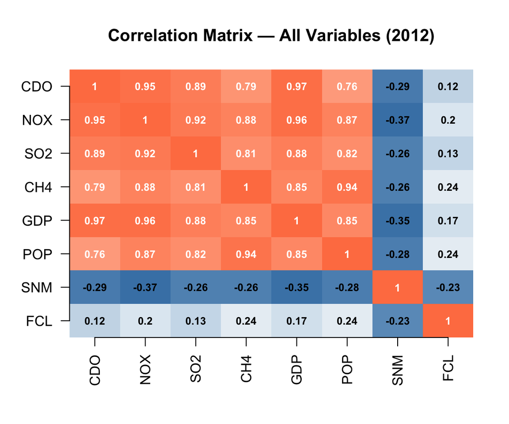

```r
vars <- c("log_CDO", "log_NOX", "log_SO2", "log_CH4",
          "log_GDP", "log_POP", "log_SNM", "log_FCL")

cor_matrix <- cor(temp[, vars], use = "complete.obs")
labels <- c("CDO", "NOX", "SO2", "CH4", "GDP", "POP", "SNM", "FCL")
rownames(cor_matrix) <- labels
colnames(cor_matrix) <- labels

n <- length(labels)
col_palette <- colorRampPalette(c("steelblue", "white", "coral"))(99)

image(1:n, 1:n, t(cor_matrix[n:1, ]),
      col = col_palette, axes = FALSE,
      xlab = "", ylab = "",
      main = "Correlation Matrix — All Variables (2012)")
axis(1, at = 1:n, labels = labels, las = 2)
axis(2, at = 1:n, labels = rev(labels), las = 1)

for (i in 1:n) {
  for (j in 1:n) {
    text(j, n + 1 - i, round(cor_matrix[i, j], 2),
         cex = 0.75, font = 2,
         col = ifelse(abs(cor_matrix[i, j]) > 0.6, "white", "black"))
  }
}
```

## Build Analysis Datasets

```r
library(dplyr)
library(stargazer)
build_year_df <- function(data, year) {
  out <- data.frame(
    country = data$country,
    iso     = data$iso,
    POP     = data[[paste0("POP.raw.", year)]],
    CDO     = data[[paste0("CDO.raw.", year)]],
    SO2     = data[[paste0("SO2.raw.", year)]],
    FCL     = data[[paste0("FCL.raw.", year)]],
    GDP     = data[[paste0("GDP.raw.", year)]],
    GDP_pc  = data[[paste0("GPC.raw.", year)]],
    HPE     = data[[paste0("HPE.raw.", year)]],
    SNM     = data[[paste0("SNM.raw.", year)]]
  )
  # Log transform raw variables
  out$log_CDO <- log(pmax(out$CDO, 1e-10))
  out$log_SO2 <- log(pmax(out$SO2, 1e-10))
  out$log_FCL <- log(pmax(out$FCL, 1e-10))
  out$log_GDP <- log(pmax(out$GDP, 1e-10))
  out$log_POP <- log(pmax(out$POP, 1e-10))
  out$log_SNM <- log(pmax(out$SNM, 1e-10))
  # HPE used as-is (already a rate/index)
  out$year    <- year
  na.omit(out)
}

df_train <- build_year_df(df, 2012)
df_test  <- build_year_df(df, 2021)

cat("Training set (2012):", nrow(df_train), "countries\n")
```

```
## Training set (2012): 133 countries
```

```r
cat("Test set    (2021):", nrow(df_test),  "countries\n")
```

```
## Test set    (2021): 132 countries
```

## Exploratory Data Analysis

### Raw vs Log Distributions

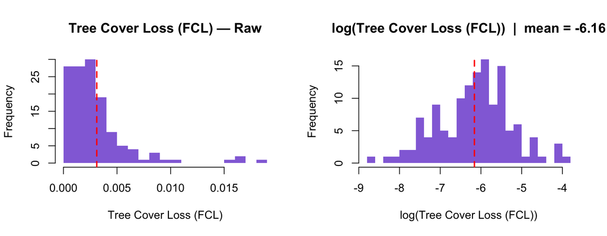

```r
plot_raw_log_hist <- function(df, raw_col, log_col, label, col) {
  par(mfrow = c(1, 2))
  hist(df[[raw_col]], breaks = 25, col = col, border = NA,
       main = paste0(label, " — Raw"),
       xlab = label)
  abline(v = mean(df[[raw_col]], na.rm = TRUE), col = "red", lwd = 2, lty = 2)
  hist(df[[log_col]], breaks = 25, col = col, border = NA,
       main = paste0("log(", label, ")  |  mean = ",
                     round(mean(df[[log_col]], na.rm = TRUE), 2)),
       xlab = paste0("log(", label, ")"))
  abline(v = mean(df[[log_col]], na.rm = TRUE), col = "red", lwd = 2, lty = 2)
  par(mfrow = c(1, 1))
}

plot_raw_log_hist(df_train, "FCL",  "log_FCL", "Tree Cover Loss (FCL)", "mediumpurple")
```

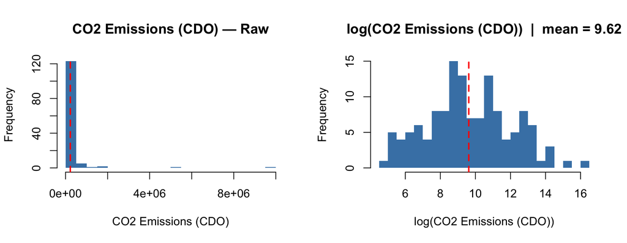

```r
plot_raw_log_hist(df_train, "CDO",  "log_CDO", "CO2 Emissions (CDO)",   "steelblue")
```

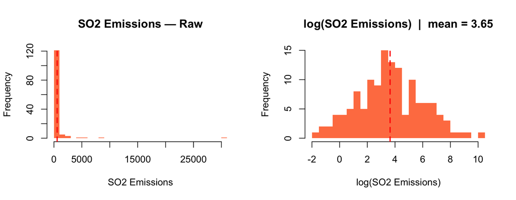

```r
plot_raw_log_hist(df_train, "SO2",  "log_SO2", "SO2 Emissions",         "coral")
```

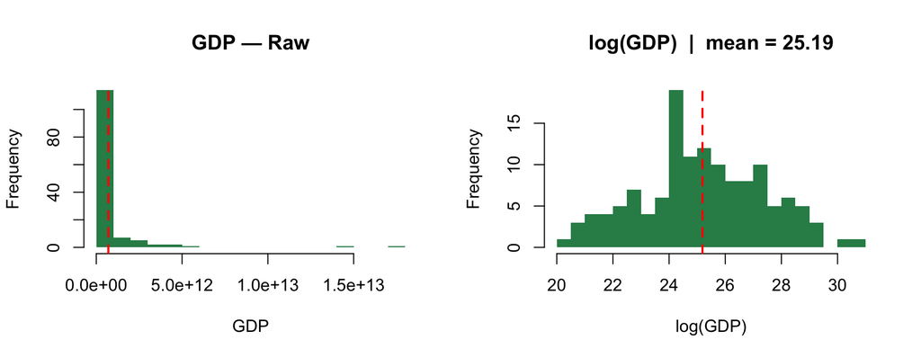

```r
plot_raw_log_hist(df_train, "GDP",  "log_GDP", "GDP",                   "seagreen")
```

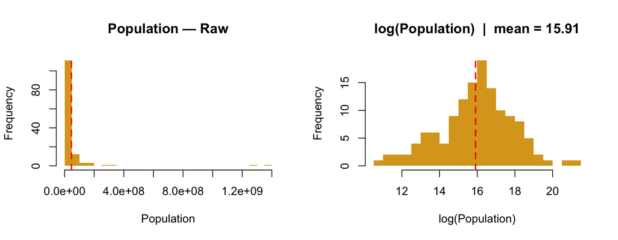

```r
plot_raw_log_hist(df_train, "POP",  "log_POP", "Population",            "goldenrod")
```

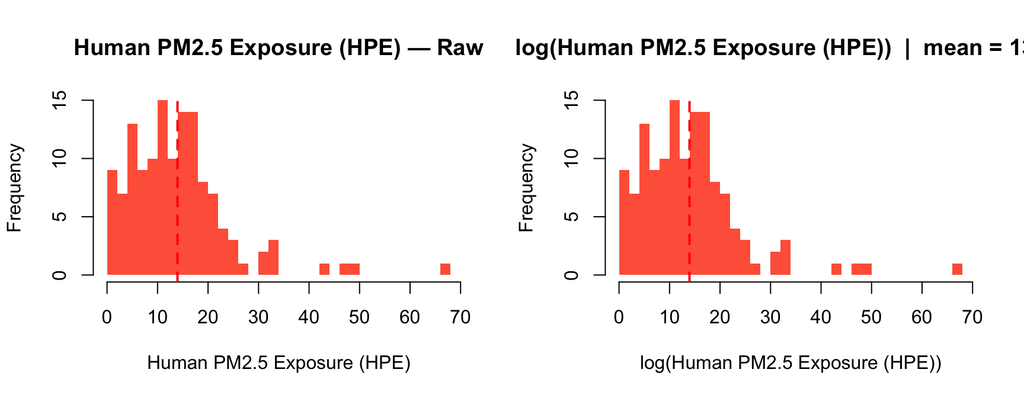

```r
plot_raw_log_hist(df_train, "HPE", "HPE", "Human PM2.5 Exposure (HPE)", "tomato")
```

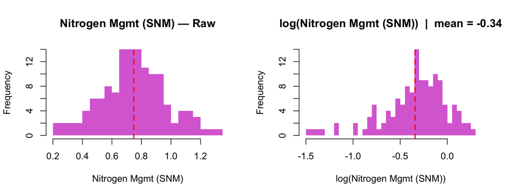

```r
plot_raw_log_hist(df_train, "SNM",  "log_SNM", "Nitrogen Mgmt (SNM)",   "orchid")
```

### Scatterplots: X vs Y

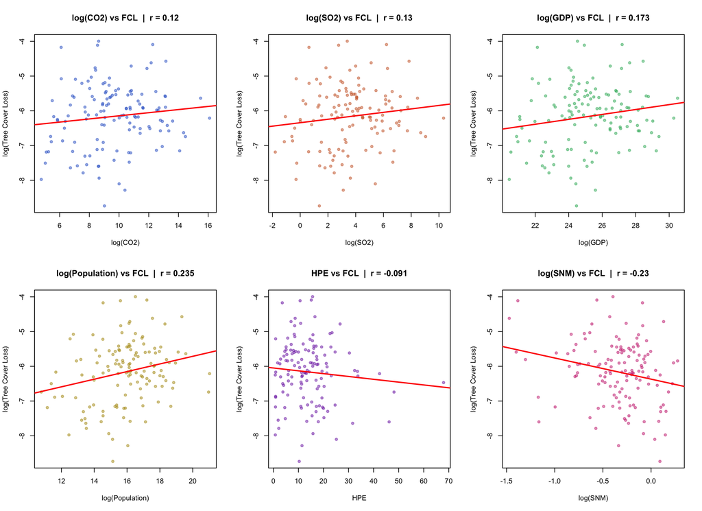

```r
par(mfrow = c(2, 3))

scatter_fcl <- function(df, xcol, xlabel, col) {
  plot(df[[xcol]], df$log_FCL,
       xlab = xlabel, ylab = "log(Tree Cover Loss)",
       main = paste0(xlabel, " vs FCL  |  r = ",
                     round(cor(df[[xcol]], df$log_FCL, use = "complete.obs"), 3)),
       pch = 19, col = col, cex = 0.8)
  abline(lm(log_FCL ~ df[[xcol]], data = df), col = "red", lwd = 2)
}

scatter_fcl(df_train, "log_CDO", "log(CO2)",       rgb(0.2, 0.4, 0.8, 0.5))
scatter_fcl(df_train, "log_SO2", "log(SO2)",       rgb(0.8, 0.4, 0.2, 0.5))
scatter_fcl(df_train, "log_GDP", "log(GDP)",       rgb(0.2, 0.7, 0.4, 0.5))
scatter_fcl(df_train, "log_POP", "log(Population)",rgb(0.7, 0.6, 0.1, 0.5))
scatter_fcl(df_train, "HPE",     "HPE",            rgb(0.5, 0.2, 0.7, 0.5))
scatter_fcl(df_train, "log_SNM", "log(SNM)",       rgb(0.8, 0.2, 0.5, 0.5))
```

```r
par(mfrow = c(1, 1))
```

### Correlation Matrix

```r
cor_vars <- df_train[, c("log_CDO", "log_SO2", "log_GDP",
                          "log_POP", "HPE", "SNM", "log_FCL")]
round(cor(cor_vars, use = "complete.obs"), 3)
```

```
##         log_CDO log_SO2 log_GDP log_POP    HPE    SNM log_FCL
## log_CDO   1.000   0.894   0.970   0.764  0.228 -0.337   0.120
## log_SO2   0.894   1.000   0.881   0.816  0.347 -0.306   0.130
## log_GDP   0.970   0.881   1.000   0.845  0.286 -0.396   0.173
## log_POP   0.764   0.816   0.845   1.000  0.466 -0.339   0.235
## HPE       0.228   0.347   0.286   0.466  1.000 -0.160  -0.091
## SNM      -0.337  -0.306  -0.396  -0.339 -0.160  1.000  -0.233
## log_FCL   0.120   0.130   0.173   0.235 -0.091 -0.233   1.000
```

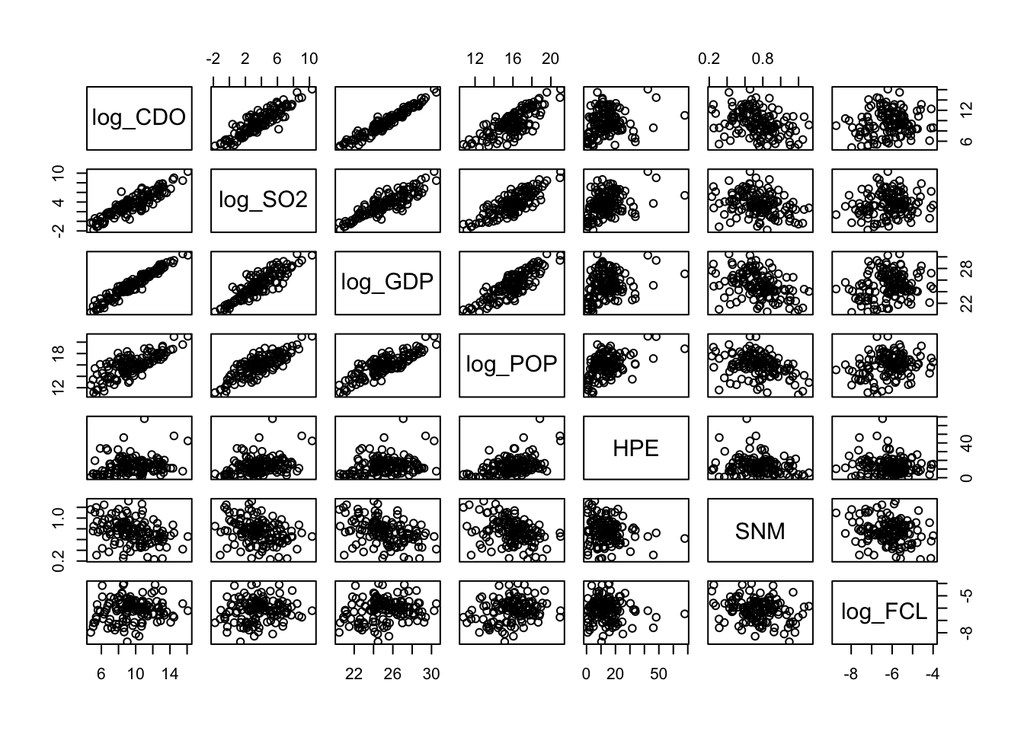

```r
pairs(cor_vars)
```

## Models

All models use log(FCL) as the outcome. Raw emissions (CDO) are log-transformed. Population is included throughout to account for country size.

### Model 1: log(CDO) + log(POP)

```r
m1 <- lm(log_FCL ~ log_CDO + log_POP, data = df_train)
summary(m1)
```

```
##
## Call:
## lm(formula = log_FCL ~ log_CDO + log_POP, data = df_train)
##
## Residuals:
##      Min       1Q   Median       3Q      Max
## -2.48295 -0.53589  0.04993  0.54353  2.04335
##
## Coefficients:
##             Estimate Std. Error t value Pr(>|t|)
## (Intercept) -8.20533    0.69036 -11.886  < 2e-16 ***
## log_CDO     -0.05379    0.04932  -1.091  0.27747
## log_POP      0.16101    0.06138   2.623  0.00975 **
## ---
## Signif. codes:  0 '***' 0.001 '**' 0.01 '*' 0.05 '.' 0.1 ' ' 1
##
## Residual standard error: 0.8825 on 130 degrees of freedom
## Multiple R-squared:  0.06401,    Adjusted R-squared:  0.04961
## F-statistic: 4.445 on 2 and 130 DF,  p-value: 0.01357
```

### Model 2a: log(CDO) + log(GDP) + log(POP)

```r
m2a <- lm(log_FCL ~ log_CDO + log_GDP + log_POP, data = df_train)
summary(m2a)
```

```
##
## Call:
## lm(formula = log_FCL ~ log_CDO + log_GDP + log_POP, data = df_train)
##
## Residuals:
##     Min      1Q  Median      3Q     Max
## -2.4646 -0.5562  0.0730  0.5661  2.0673
##
## Coefficients:
##              Estimate Std. Error t value Pr(>|t|)
## (Intercept) -11.67695    2.71350  -4.303  3.3e-05 ***
## log_CDO      -0.23348    0.14449  -1.616    0.109
## log_GDP       0.25189    0.19045   1.323    0.188
## log_POP       0.08908    0.08187   1.088    0.279
## ---
## Signif. codes:  0 '***' 0.001 '**' 0.01 '*' 0.05 '.' 0.1 ' ' 1
##
## Residual standard error: 0.8799 on 129 degrees of freedom
## Multiple R-squared:  0.07654,    Adjusted R-squared:  0.05506
## F-statistic: 3.564 on 3 and 129 DF,  p-value: 0.0161
```

### Model 2b: log(CDO) + log(POP) + HPE

HPE (human PM2.5 pollution exposure) as a proxy for industrial maturity instead of GDP, which is nearly collinear with CDO.

```r
m2b <- lm(log_FCL ~ log_CDO + log_POP + HPE, data = df_train)
summary(m2b)
```

```
##
## Call:
## lm(formula = log_FCL ~ log_CDO + log_POP + HPE, data = df_train)
##
## Residuals:
##      Min       1Q   Median       3Q      Max
## -2.52417 -0.52429  0.02659  0.48173  1.99944
##
## Coefficients:
##              Estimate Std. Error t value Pr(>|t|)
## (Intercept) -9.046151   0.721783 -12.533  < 2e-16 ***
## log_CDO     -0.088059   0.049039  -1.796 0.074882 .
## log_POP      0.257809   0.067179   3.838 0.000194 ***
## HPE         -0.026505   0.008566  -3.094 0.002422 **
## ---
## Signif. codes:  0 '***' 0.001 '**' 0.01 '*' 0.05 '.' 0.1 ' ' 1
##
## Residual standard error: 0.8547 on 129 degrees of freedom
## Multiple R-squared:  0.1287, Adjusted R-squared:  0.1084
## F-statistic:  6.35 on 3 and 129 DF,  p-value: 0.0004755
```

Adds the best agricultural variable (Sustainable Nitrogen Management Index) to test whether agricultural pressure explains forest loss beyond industrial emissions.

```r
m2c <- lm(log_FCL ~ log_CDO + log_POP + HPE + SNM, data = df_train)
summary(m2c)
```

```
##
## Call:
## lm(formula = log_FCL ~ log_CDO + log_POP + HPE + SNM, data = df_train)
##
## Residuals:
##      Min       1Q   Median       3Q      Max
## -2.27142 -0.49728  0.03221  0.50754  1.91733
##
## Coefficients:
##              Estimate Std. Error t value Pr(>|t|)
## (Intercept) -8.050695   0.834754  -9.644  < 2e-16 ***
## log_CDO     -0.102539   0.048686  -2.106 0.037147 *
## log_POP      0.241844   0.066494   3.637 0.000398 ***
## HPE         -0.027108   0.008436  -3.213 0.001660 **
## SNM         -0.793153   0.349230  -2.271 0.024808 *
## ---
## Signif. codes:  0 '***' 0.001 '**' 0.01 '*' 0.05 '.' 0.1 ' ' 1
##
## Residual standard error: 0.8413 on 128 degrees of freedom
## Multiple R-squared:  0.1624, Adjusted R-squared:  0.1362
## F-statistic: 6.205 on 4 and 128 DF,  p-value: 0.000135
```

### Model 3a: log(CDO) * log(GDP) + log(POP)

Interaction version of Model 2a — tests whether the CDO to FCL relationship changes with GDP level (EKC hypothesis).

```r
m3a <- lm(log_FCL ~ log_CDO * log_GDP + log_POP, data = df_train)
summary(m3a)
```

```
##
## Call:
## lm(formula = log_FCL ~ log_CDO * log_GDP + log_POP, data = df_train)
##
## Residuals:
##      Min       1Q   Median       3Q      Max
## -2.54950 -0.51383  0.05776  0.57303  2.17263
##
## Coefficients:
##                  Estimate Std. Error t value Pr(>|t|)
## (Intercept)     -15.21759    3.62531  -4.198 5.01e-05 ***
## log_CDO           0.24707    0.35827   0.690   0.4917
## log_GDP           0.37603    0.20769   1.811   0.0726 .
## log_POP           0.09704    0.08169   1.188   0.2371
## log_CDO:log_GDP  -0.01752    0.01196  -1.465   0.1455
## ---
## Signif. codes:  0 '***' 0.001 '**' 0.01 '*' 0.05 '.' 0.1 ' ' 1
##
## Residual standard error: 0.8761 on 128 degrees of freedom
## Multiple R-squared:  0.09175,    Adjusted R-squared:  0.06337
## F-statistic: 3.233 on 4 and 128 DF,  p-value: 0.01452
```

### Model 3b: log(CDO) * HPE + log(POP)

Interaction version of Model 2b — tests whether the CDO to FCL relationship changes with industrial maturity level.

```r
m3b <- lm(log_FCL ~ log_CDO * HPE + log_POP, data = df_train)
summary(m3b)
```

```
##
## Call:
## lm(formula = log_FCL ~ log_CDO * HPE + log_POP, data = df_train)
##
## Residuals:
##      Min       1Q   Median       3Q      Max
## -2.52596 -0.51512  0.03236  0.48052  1.99817
##
## Coefficients:
##              Estimate Std. Error t value Pr(>|t|)
## (Intercept) -9.104548   0.768444 -11.848  < 2e-16 ***
## log_CDO     -0.079393   0.062201  -1.276  0.20413
## HPE         -0.020688   0.026937  -0.768  0.44390
## log_POP      0.256196   0.067797   3.779  0.00024 ***
## log_CDO:HPE -0.000576   0.002528  -0.228  0.82011
## ---
## Signif. codes:  0 '***' 0.001 '**' 0.01 '*' 0.05 '.' 0.1 ' ' 1
##
## Residual standard error: 0.8579 on 128 degrees of freedom
## Multiple R-squared:  0.129,  Adjusted R-squared:  0.1018
## F-statistic:  4.74 on 4 and 128 DF,  p-value: 0.001339
```

Interaction version of Model 2c — adds the agricultural term on top of the CDO * HPE interaction.

```r
m3c <- lm(log_FCL ~ log_CDO * HPE + log_POP + SNM, data = df_train)
summary(m3c)
```

```
##
## Call:
## lm(formula = log_FCL ~ log_CDO * HPE + log_POP + SNM, data = df_train)
##
## Residuals:
##      Min       1Q   Median       3Q      Max
## -2.27307 -0.49226  0.02622  0.50511  1.91683
##
## Coefficients:
##               Estimate Std. Error t value Pr(>|t|)
## (Intercept) -8.0857086  0.8812154  -9.176 1.04e-15 ***
## log_CDO     -0.0976878  0.0617680  -1.582 0.116244
## HPE         -0.0238754  0.0265550  -0.899 0.370305
## log_POP      0.2409901  0.0670818   3.592 0.000467 ***
## SNM         -0.7910970  0.3509448  -2.254 0.025898 *
## log_CDO:HPE -0.0003199  0.0024910  -0.128 0.898015
## ---
## Signif. codes:  0 '***' 0.001 '**' 0.01 '*' 0.05 '.' 0.1 ' ' 1
##
## Residual standard error: 0.8445 on 127 degrees of freedom
## Multiple R-squared:  0.1625, Adjusted R-squared:  0.1296
## F-statistic:  4.93 on 5 and 127 DF,  p-value: 0.0003707
```

### Model 4: log(CDO) + log(POP) + HPE + SNM + Coastal/Landlocked

Builds on Model 2c by adding a binary geographic indicator for whether a country is landlocked or coastal. Landlocked countries lack ocean access and may have different deforestation patterns than coastal nations.

```r
library(tidyr)

landlocked <- c(
  "Afghanistan", "Armenia", "Azerbaijan", "Bhutan", "Bolivia",
  "Botswana", "Burkina Faso", "Burundi", "Central African Republic",
  "Chad", "Czech Republic", "Ethiopia", "Hungary", "Kazakhstan",
  "Kyrgyzstan", "Laos", "Lesotho", "Luxembourg", "Malawi",
  "Mali", "Moldova", "Mongolia", "Nepal", "Niger",
  "North Macedonia", "Paraguay", "Rwanda", "Serbia",
  "Slovakia", "South Sudan", "Eswatini", "Switzerland",
  "Tajikistan", "Turkmenistan", "Uganda", "Uzbekistan",
  "Zambia", "Zimbabwe", "Austria", "Belarus"
)

df_train$type <- ifelse(df_train$country %in% landlocked, "landlocked", "coastal")
df_test$type  <- ifelse(df_test$country  %in% landlocked, "landlocked", "coastal")

df_train %>% count(type)
```

```
##         type   n
## 1    coastal 106
## 2 landlocked  27
```

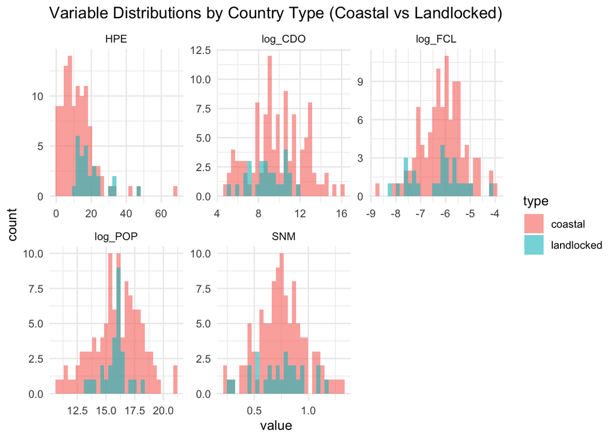

```r
vars <- df_train %>%
  select(log_FCL, log_CDO, log_POP, HPE, SNM, type) %>%
  pivot_longer(cols = -type, names_to = "variable", values_to = "value")

ggplot(vars, aes(x = value, fill = type)) +
  geom_histogram(alpha = 0.6, bins = 30, position = "identity") +
  facet_wrap(~variable, scales = "free") +
  theme_minimal() +
  labs(title = "Variable Distributions by Country Type (Coastal vs Landlocked)")
```

```r
m4 <- lm(log_FCL ~ log_CDO + log_POP + HPE + SNM + type, data = df_train)
summary(m4)
```

```
##
## Call:
## lm(formula = log_FCL ~ log_CDO + log_POP + HPE + SNM + type,
##     data = df_train)
##
## Residuals:
##      Min       1Q   Median       3Q      Max
## -2.28806 -0.51759  0.02895  0.53095  1.90182
##
## Coefficients:
##                 Estimate Std. Error t value Pr(>|t|)
## (Intercept)    -7.972550   0.845620  -9.428 2.54e-16 ***
## log_CDO        -0.107967   0.049536  -2.180 0.031135 *
## log_POP         0.241204   0.066657   3.619 0.000426 ***
## HPE            -0.025423   0.008859  -2.870 0.004812 **
## SNM            -0.811618   0.351238  -2.311 0.022460 *
## typelandlocked -0.125219   0.196346  -0.638 0.524787
## ---
## Signif. codes:  0 '***' 0.001 '**' 0.01 '*' 0.05 '.' 0.1 ' ' 1
##
## Residual standard error: 0.8432 on 127 degrees of freedom
## Multiple R-squared:  0.1651, Adjusted R-squared:  0.1322
## F-statistic: 5.023 on 5 and 127 DF,  p-value: 0.0003117
```

### Model 5: log(CDO) + log(POP) + HPE + SNM + Continent

Builds on Model 2c by adding continent as a categorical variable. Continent captures broad geographic and ecological differences — tropical continents like Africa and South America have far more forest cover and deforestation pressure than Europe or Oceania.

```r
library(countrycode)

df_train$continent <- countrycode(df_train$iso, origin = "iso3c",
                                   destination = "continent")
df_test$continent  <- countrycode(df_test$iso,  origin = "iso3c",
                                   destination = "continent")

m5 <- lm(log_FCL ~ log_CDO + log_POP + HPE + SNM + continent,
         data = df_train)
summary(m5)
```

```
##
## Call:
## lm(formula = log_FCL ~ log_CDO + log_POP + HPE + SNM + continent,
##     data = df_train)
##
## Residuals:
##      Min       1Q   Median       3Q      Max
## -2.23895 -0.56375  0.02677  0.49371  1.94862
##
## Coefficients:
##                    Estimate Std. Error t value Pr(>|t|)
## (Intercept)       -7.951157   1.127453  -7.052 1.09e-10 ***
## log_CDO           -0.100366   0.074913  -1.340  0.18277
## log_POP            0.238991   0.092544   2.582  0.01097 *
## HPE               -0.028707   0.009652  -2.974  0.00353 **
## SNM               -0.807827   0.372019  -2.171  0.03180 *
## continentAmericas  0.101606   0.281749   0.361  0.71899
## continentAsia     -0.075826   0.294544  -0.257  0.79727
## continentEurope   -0.059957   0.321461  -0.187  0.85235
## continentOceania  -0.793015   0.411337  -1.928  0.05615 .
## ---
## Signif. codes:  0 '***' 0.001 '**' 0.01 '*' 0.05 '.' 0.1 ' ' 1
##
## Residual standard error: 0.8351 on 124 degrees of freedom
## Multiple R-squared:  0.2005, Adjusted R-squared:  0.149
## F-statistic: 3.888 on 8 and 124 DF,  p-value: 0.0004027
```

### Regression Table

```r
stargazer(m1, m2a, m2b, m2c, m3a, m3b, m3c,
          type             = "text",
          title            = "Tree Cover Loss on Industrial Activity (Training Year: 2012)",
          dep.var.labels   = "log(Tree Cover Loss)",
          covariate.labels = c("log(CO2)",
                               "log(GDP)",
                               "log(Population)",
                               "HPE",
                               "log(SNM)",
                               "log(CO2) x log(GDP)",
                               "log(CO2) x HPE"),
          omit.stat        = c("f", "ser"),
          star.cutoffs     = c(0.05, 0.01, 0.001))
```

# Tree Cover Loss on Industrial Activity (Training Year: 2012)

```
                                          Dependent variable:
                -----------------------------------------------------------------------
                                         log(Tree Cover Loss)
                   (1)       (2)        (3)       (4)       (5)        (6)       (7)
```

[output not shown]

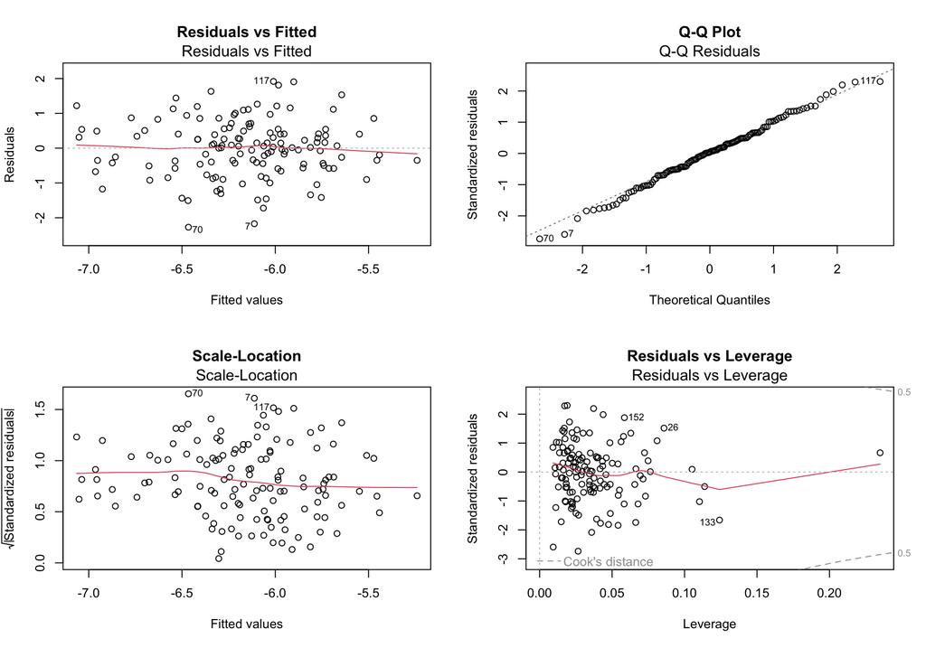

```r
par(mfrow = c(2, 2))
plot(m2c, which = 1, main = "Residuals vs Fitted")
plot(m2c, which = 2, main = "Q-Q Plot")
plot(m2c, which = 3, main = "Scale-Location")
plot(m2c, which = 5, main = "Residuals vs Leverage")
```

```r
par(mfrow = c(1, 1))
```

```r
cat("=== VIF (Model 2c) ===\n")
```

```
## === VIF (Model 2c) ===
```

```r
print(round(vif(m2c), 3))
```

```
## log_CDO log_POP     HPE     SNM
##   2.578   3.105   1.348   1.150
```

```r
cat("\n=== Breusch-Pagan Test (Model 2c) ===\n")
```

```
##
## === Breusch-Pagan Test (Model 2c) ===
```

```r
print(bptest(m2c))
```

```
##
##  studentized Breusch-Pagan test
##
## data:  m2c
## BP = 3.52, df = 4, p-value = 0.4748
```

## Out-of-Sample Test (2021)

Using Model 2c as the primary evaluation model.

```r
df_test$predicted <- predict(m2c, newdata = df_test)

rmse_train <- round(sqrt(mean(residuals(m2c)^2)), 4)
rmse_test  <- round(sqrt(mean((df_test$log_FCL - df_test$predicted)^2,
                               na.rm = TRUE)), 4)

ss_res <- sum((df_test$log_FCL - df_test$predicted)^2, na.rm = TRUE)
ss_tot <- sum((df_test$log_FCL - mean(df_test$log_FCL))^2, na.rm = TRUE)
r2_test <- round(1 - ss_res / ss_tot, 4)

cat("RMSE (train, 2012):", rmse_train, "\n")
```

```
## RMSE (train, 2012): 0.8253
```

```r
cat("RMSE (test,  2021):", rmse_test,  "\n")
```

```
## RMSE (test,  2021): 1.1078
```

```r
cat("R2   (train, 2012):", round(summary(m2c)$r.squared, 4), "\n")
```

```
## R2   (train, 2012): 0.1624
```

```r
cat("R2   (test,  2021):", r2_test, "\n")
```

```
## R2   (test,  2021): 0.0942
```

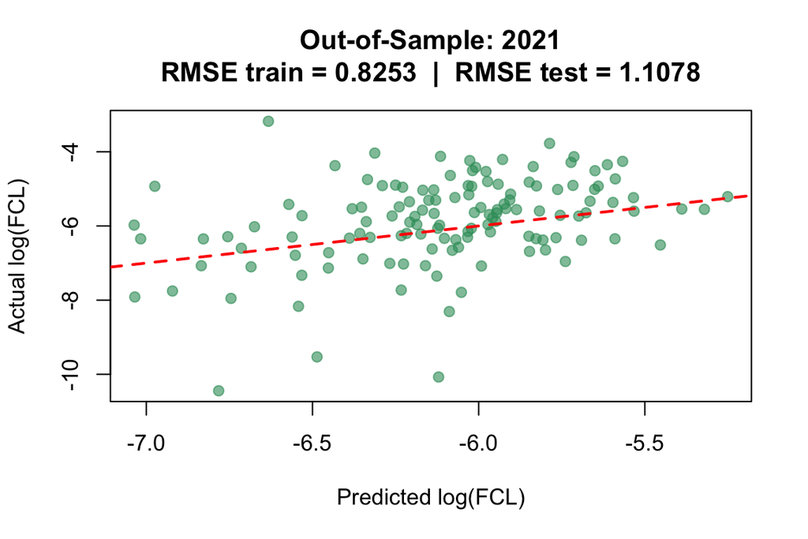

```r
plot(df_test$predicted, df_test$log_FCL,
     xlab = "Predicted log(FCL)", ylab = "Actual log(FCL)",
     main = paste0("Out-of-Sample: 2021\n",
                   "RMSE train = ", rmse_train,
                   "  |  RMSE test = ", rmse_test),
     pch = 19, col = rgb(0.2, 0.6, 0.4, 0.6))
abline(0, 1, col = "red", lwd = 2, lty = 2)
```